# beanz: Bayesian Analysis of Heterogeneous Treatment Effect

Chenguang Wang and Ravi Varadhan

2017-03-29

# Introduction

In patient-centered outcomes research, it is vital to assess the heterogeneity of treatment effects (HTE) when making health care decisions for an individual patient or a group of patients. Nevertheless, it remains challenging to evaluate HTE based on information collected from clinical studies that are often designed and conducted to evaluate the efficacy of a treatment for the overall population. The Bayesian framework offers a principled and flexible approach to estimate and compare treatment effects across subgroups of patients defined by their characteristics.

*R* package **beanz** provides functions to facilitate the conduct of Bayesian analysis of HTE and a web-based graphical user interface for users to conduct such Bayesian analysis in an interactive and user-friendly manner.

# Data accepted by **beanz**

There are two types of data structures that **beanz** recognizes:

- Summary treatment effect data: Each row should represent a subgroup with covariates that define the subgroup, estimated treatment effect in the subgroup and variance for the estimation.
- Patient level raw data: Each row should represent a patient with covariates that define the subgroup in which the patient belongs to, treatment indicator and outcome. The outcome can be binary, continuous, or time to event.

The **beanz** package provides dataset *solvd.sub* from the *SOLVD* trial as an example *Patient level raw data* dataset.

# Estimate subgroup effect

If *Patient level raw data* is provided, the package provides function *bzGetSubgrpRaw* for estimating subgroup effect for each subgroup. The return value from *bzGetSubgrpRaw* is a data frame with the format of *Summary treatment effect data*.

The example is as follows:

```r
var.cov    <- c("sodium", "lvef", "any.vasodilator.use");
var.resp   <- "y";
var.trt    <- "trt";
var.censor <- "censor";
resptype   <- "survival";

subgrp.effect <- bzGetSubgrpRaw(solvd.sub,
                                  var.resp   = var.resp,
                                  var.trt    = var.trt,
                                  var.cov    = var.cov,
                                  var.censor = var.censor,
                                  resptype   = resptype);
print(subgrp.effect);
```

```
##   Subgroup sodium lvef any.vasodilator.use    Estimate   Variance   N
## 1        1      0    0                   0 -0.37783038 0.01212786 562
## 2        2      0    0                   1 -0.34655336 0.01004499 695
## 3        3      0    1                   0  0.06776454 0.04629163 223
## 4        4      0    1                   1 -0.23655764 0.02400353 341
## 5        5      1    0                   0 -0.79235451 0.03939983 237
## 6        6      1    0                   1 -0.39334304 0.02969421 250
## 7        7      1    1                   0  0.15435495 0.10365396 104
## 8        8      1    1                   1  0.05947290 0.07761840 123
```

# Bayesian HTE models

The function *bzCallStan* calls *rstan::sampling* to draw samples for different Bayesian models. The following models are available in the current version of **beanz**:

- *nse*: No subgroup effect model
- *fs*: Full stratification model
- *sr*: Simple regression model
- *bs*: Basic shrinkage model
- *srs*: Simple regression with shrinkage model
- *ds*: Dixon-Simon model
- *eds*: Extended Dixon-Simon model.

The following examples show how *No subgroup effect model* (*nse),* Simple regression model* (*sr*) and *Basic shrinkage model* (*bs*) are called:

```r
var.cov    <- c("sodium", "lvef", "any.vasodilator.use");
var.estvar <- c("Estimate", "Variance");

rst.nse <- bzCallStan("nse", dat.sub=subgrp.effect,
                     var.estvar = var.estvar, var.cov = var.cov,
                     par.pri = c(B=1000),
                     chains=4, iter=4000,
                     warmup=2000, seed=1000);
```

[output not shown]

[output cut: 16 more lines]

[output not shown]

```r
rst.sr  <- bzCallStan("sr", dat.sub=subgrp.effect,
                     var.estvar = var.estvar, var.cov = var.cov,
                     par.pri = c(B=1000, C=1000),
                     chains=4, iter=4000,
                     warmup=2000,  seed=1000);
```

[output not shown]

[output cut: 16 more lines]

[output not shown]

```r
rst.bs  <- bzCallStan("bs", dat.sub=subgrp.effect,
                     var.estvar = var.estvar, var.cov = var.cov,
                     par.pri = c(B=1000, D=1),
                     chains=4, iter=4000, warmup=2000,  seed=1000);
```

[output not shown]

[output cut: 16 more lines]

[output not shown]

# Results presentation

## Posterior subgroup treatment effect summary

Posterior subgroup treatment effect can be summarized and presented by functions *bzSummary*, *bzPlot* and *bzForest*. These functions allows to include a subgroup from another model (i.e. No subgroup effect model) as a reference in the results.

### Simple regression model

```r
sel.grps <- c(1,4,5);
tbl.sub <- bzSummary(rst.sr, ref.stan.rst=rst.nse, ref.sel.grps=1);
print(tbl.sub);
```

```
##                       Subgroup                Mean     SD      2.5%
## Subgroup 1            "Subgroup 1"            "-0.403" "0.095" "-0.591"
## Subgroup 2            "Subgroup 2"            "-0.381" "0.088" "-0.557"
## Subgroup 3            "Subgroup 3"            "-0.063" "0.136" "-0.327"
## Subgroup 4            "Subgroup 4"            "-0.041" "0.122" "-0.28"
## Subgroup 5            "Subgroup 5"            "-0.487" "0.13"  "-0.745"
## Subgroup 6            "Subgroup 6"            "-0.465" "0.128" "-0.721"
## Subgroup 7            "Subgroup 7"            "-0.147" "0.16"  "-0.461"
## Subgroup 8            "Subgroup 8"            "-0.125" "0.151" "-0.42"
## No subgroup effect(1) "No subgroup effect(1)" "-0.322" "0.055" "-0.429"
##                       25%      Median   75%      97.5%    Prob < 0
## Subgroup 1            "-0.467" "-0.402" "-0.338" "-0.216" "1"
## Subgroup 2            "-0.441" "-0.381" "-0.32"  "-0.212" "1"
## Subgroup 3            "-0.156" "-0.064" "0.033"  "0.204"  "0.674"
## Subgroup 4            "-0.124" "-0.042" "0.041"  "0.199"  "0.638"
## Subgroup 5            "-0.574" "-0.485" "-0.397" "-0.24"  "1"
## Subgroup 6            "-0.552" "-0.463" "-0.378" "-0.218" "1"
## Subgroup 7            "-0.258" "-0.146" "-0.036" "0.165"  "0.823"
## Subgroup 8            "-0.225" "-0.124" "-0.026" "0.173"  "0.797"
## No subgroup effect(1) "-0.359" "-0.322" "-0.284" "-0.213" "1"
```

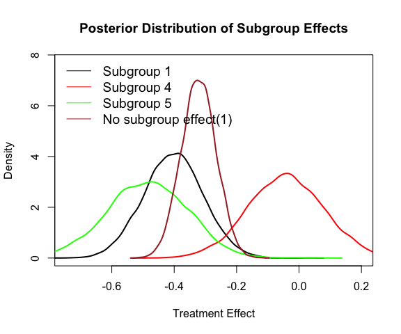

```r
bzPlot(rst.sr, sel.grps = sel.grps, ref.stan.rst=rst.nse, ref.sel.grps=1);
```

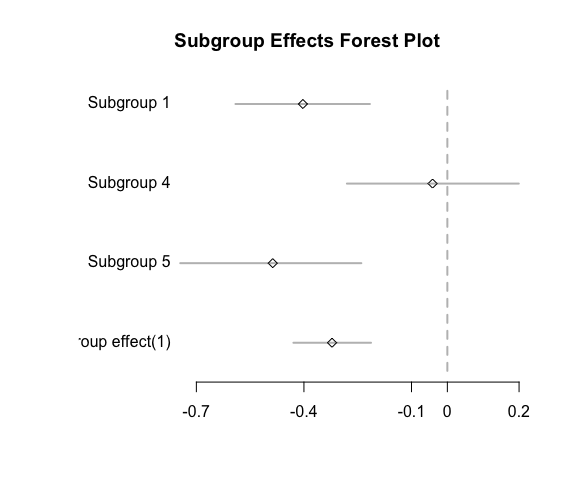

```r
bzForest(rst.sr, sel.grps = sel.grps, ref.stan.rst=rst.nse, ref.sel.grps=1);
```

### Basic shrinkage model

```r
tbl.sub <- bzSummary(rst.bs, ref.stan.rst=rst.nse, ref.sel.grps=1);
print(tbl.sub);
```

```
##                       Subgroup                Mean     SD      2.5%
## Subgroup 1            "Subgroup 1"            "-0.35"  "0.093" "-0.539"
## Subgroup 2            "Subgroup 2"            "-0.331" "0.087" "-0.505"
## Subgroup 3            "Subgroup 3"            "-0.147" "0.182" "-0.434"
## Subgroup 4            "Subgroup 4"            "-0.267" "0.123" "-0.497"
## Subgroup 5            "Subgroup 5"            "-0.513" "0.186" "-0.923"
## Subgroup 6            "Subgroup 6"            "-0.343" "0.13"  "-0.606"
## Subgroup 7            "Subgroup 7"            "-0.17"  "0.211" "-0.483"
## Subgroup 8            "Subgroup 8"            "-0.181" "0.196" "-0.501"
## No subgroup effect(1) "No subgroup effect(1)" "-0.322" "0.055" "-0.429"
##                       25%      Median   75%      97.5%    Prob < 0
## Subgroup 1            "-0.409" "-0.348" "-0.289" "-0.17"  "1"
## Subgroup 2            "-0.387" "-0.33"  "-0.273" "-0.162" "1"
## Subgroup 3            "-0.285" "-0.171" "-0.029" "0.253"  "0.792"
## Subgroup 4            "-0.346" "-0.278" "-0.191" "-0.002" "0.975"
## Subgroup 5            "-0.635" "-0.489" "-0.367" "-0.222" "1"
## Subgroup 6            "-0.422" "-0.34"  "-0.261" "-0.086" "0.995"
## Subgroup 7            "-0.318" "-0.212" "-0.054" "0.342"  "0.808"
## Subgroup 8            "-0.319" "-0.215" "-0.064" "0.276"  "0.826"
## No subgroup effect(1) "-0.359" "-0.322" "-0.284" "-0.213" "1"
```

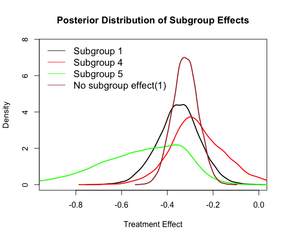

```r
bzPlot(rst.bs, sel.grps = sel.grps, ref.stan.rst=rst.nse, ref.sel.grps=1);
```

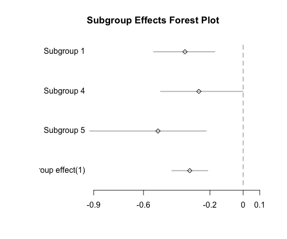

```r
bzForest(rst.bs, sel.grps = sel.grps, ref.stan.rst=rst.nse, ref.sel.grps=1);
```

## Posterior subgroup treatment effect comparison

Posterior subgroup treatment effect can be compared between subgroups by functions *bzSummaryComp*, *bzPlotComp* and *bzForestComp*.

### Simple regression model

```r
tbl.sub <- bzSummaryComp(rst.sr, sel.grps=sel.grps);
print(tbl.sub);
```

```
##              Comparison     Mean     SD      2.5%     25%      Median
## Subgroup 4-1 "Subgroup 4-1" "0.361"  "0.155" "0.058"  "0.255"  "0.361"
## Subgroup 5-1 "Subgroup 5-1" "-0.085" "0.16"  "-0.406" "-0.192" "-0.085"
## Subgroup 5-4 "Subgroup 5-4" "-0.445" "0.181" "-0.8"   "-0.566" "-0.445"
##              75%      97.5%    Prob <0
## Subgroup 4-1 "0.465"  "0.663"  "0.011"
## Subgroup 5-1 "0.024"  "0.225"  "0.699"
## Subgroup 5-4 "-0.324" "-0.089" "0.992"
```

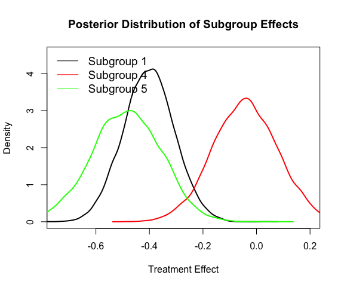

```r
bzPlot(rst.sr, sel.grps = sel.grps);
```

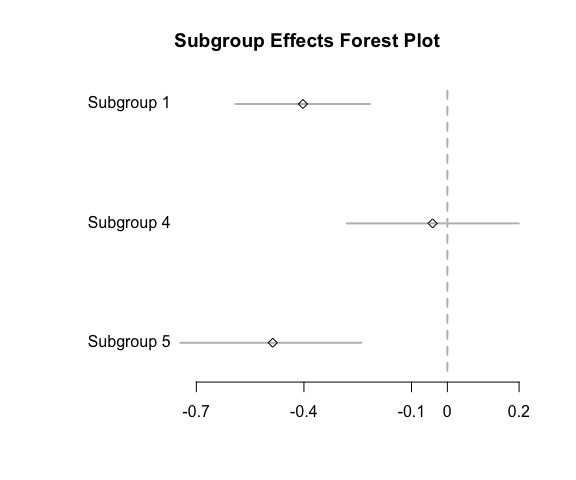

```r
bzForest(rst.sr, sel.grps = sel.grps);
```

### Basic shrinkage model

```r
tbl.sub <- bzSummaryComp(rst.bs, sel.grps=sel.grps);
print(tbl.sub);
```

```
##              Comparison     Mean     SD      2.5%     25%      Median
## Subgroup 4-1 "Subgroup 4-1" "0.084"  "0.153" "-0.205" "-0.019" "0.08"
## Subgroup 5-1 "Subgroup 5-1" "-0.16"  "0.208" "-0.611" "-0.296" "-0.143"
## Subgroup 5-4 "Subgroup 5-4" "-0.247" "0.223" "-0.719" "-0.39"  "-0.229"
##              75%      97.5%   Prob <0
## Subgroup 4-1 "0.183"  "0.403" "0.297"
## Subgroup 5-1 "-0.009" "0.194" "0.768"
## Subgroup 5-4 "-0.087" "0.139" "0.871"
```

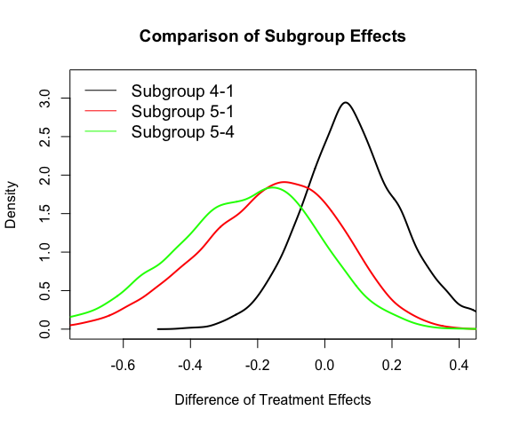

```r
bzPlotComp(rst.bs, sel.grps = sel.grps);
```

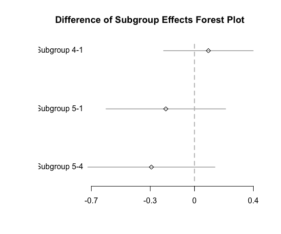

```r
bzForestComp(rst.bs, sel.grps = sel.grps);
```

## Overall summary

**beanz** provides function *bzRptTbl* to generate the summary posterior subgroup treatment effect table from the model selected by DIC (i.e. the model with the smallest DIC):

```r
lst.rst     <- list(nse=rst.nse, sr=rst.sr, bs=rst.bs);
tbl.summary <- bzRptTbl(lst.rst, dat.sub = subgrp.effect, var.cov = var.cov);
print(tbl.summary);
```

```
##                        Model Subgroup sodium lvef any.vasodilator.use
## Subgroup 1 Simple regression        1      0    0                   0
## Subgroup 2 Simple regression        2      0    0                   1
## Subgroup 3 Simple regression        3      0    1                   0
## Subgroup 4 Simple regression        4      0    1                   1
## Subgroup 5 Simple regression        5      1    0                   0
## Subgroup 6 Simple regression        6      1    0                   1
## Subgroup 7 Simple regression        7      1    1                   0
## Subgroup 8 Simple regression        8      1    1                   1
##              Mean    SD Prob < 0
## Subgroup 1 -0.403 0.095    1.000
## Subgroup 2 -0.381 0.088    1.000
## Subgroup 3 -0.063 0.136    0.674
## Subgroup 4 -0.041 0.122    0.638
## Subgroup 5 -0.487 0.130    1.000
## Subgroup 6 -0.465 0.128    1.000
## Subgroup 7 -0.147 0.160    0.823
## Subgroup 8 -0.125 0.151    0.797
```

# Predictive distribution

Function *bzPredSubgrp* generates the predictive distribution of the subgrooup treatment effects.

```r
pred.dist <- bzPredSubgrp(rst.sr,
                                  dat.sub=subgrp.effect,
                                  var.estvar = var.estvar);
head(pred.dist);
```

```
##            [,1]       [,2]       [,3]        [,4]       [,5]       [,6]
## [1,] -0.7565420 -0.4929231 -0.1276339  0.08234471 -0.7245907 -0.4895100
## [2,] -0.4374601 -0.2494721 -0.3988396 -0.19676140 -0.4421539 -0.3155644
## [3,] -0.4746674 -0.2683061 -0.3603631 -0.13281632 -0.7428027 -0.4651284
## [4,] -0.3484304 -0.1949399 -0.1966188 -0.10158126 -0.5155658 -0.3503448
## [5,] -0.4148220 -0.3703063 -0.1436131 -0.11703379 -0.6062018 -0.5563840
## [6,] -0.4649350 -0.4103694 -0.1396011 -0.01937191 -0.5229580 -0.4046580
##             [,7]        [,8]
## [1,] -0.33345491  0.02460792
## [2,] -0.46515399 -0.18584029
## [3,] -0.55441911 -0.26265905
## [4,] -0.62752288 -0.20634861
## [5,] -0.52564500 -0.32864835
## [6,] -0.02951873 -0.23821291
```

# Graphical User Interface

With package *shiny* installed, *beaz* provides a web-based graphical user interface (GUI) for conducting the HTE analysis in an user-friendly interactive manner. The GUI can be started by

```r
bzShiny();
```

# Toolbox

Package **beanz** provides function *bzGailSimon* that implements the Gail-Simon test for qualitative interactions:

```r
gs.pval <- bzGailSimon(subgrp.effect$Estimate,
                       sqrt(subgrp.effect$Variance));
print(gs.pval);
```

```
## [1] 0.9191656
```

The result show that there is no significant qualitative interactions according to the Gail-Simon test.